# CSE204 - Introduction to Machine Learning - Lab Session 4: regression methods

[CSE204-2021](https://moodle.polytechnique.fr/course/view.php?id=10682) Lab session #04

Jérémie DECOCK - Adrien EHRHARDT

## Objectives

In the lab session 02, we have used a **parametric model** to solve **regression problems**. In lab session 03, we used k-NN, a **non-parametric model** on (mostly) classification **and** regression problems, as well as logistic regression, a **parametric model** on classification tasks.

Today you will continue the exploration of regression methods (both parametric and non-parametric), and of logistic regression. On today's agenda:

- Pathological Cases: ordinary least squares gone wrong
- Regularization with linear and logistic regression
- Weighted Least Squares
- Kernel Regression: "local" dependence, like k-NN
- Local Linear Regression

**Note**: as in the previous labs, there are some differences in notations with the lecture slides. For instance, parameters are noted $w$ (machine learning community) in lectures but they are noted $\theta$ here (statistics community).

## Imports and tool functions

```python
%matplotlib inline

import math
import numpy as np
import pandas as pd
import matplotlib.pyplot as plt

import sklearn
import sklearn.linear_model
import sklearn.pipeline
import sklearn.preprocessing
from sklearn.utils import shuffle
```

```python
def gen_2d_classification_samples(n_samples: int = 20, nclass: int = 3) -> pd.DataFrame:
    """
    Generates 2-dimensional samples which belong to either 2 or 3 classes

    :param int n_samples: number of samples to draw per class
    :param int nclass: number of classes the samples belong to (either 2 or 3)
    :returns: dataframe containing X (2 coordinates x1, x2) and y (as int!)
    """
    cov = np.diag([2., 2.])

    x1 = np.random.multivariate_normal(mean=[0., 0.], cov=cov, size=n_samples)
    y1 = np.full(n_samples, 1, dtype=int)

    x2 = np.random.multivariate_normal(mean=[4., 0.], cov=cov, size=n_samples)
    y2 = np.full(n_samples, 2, dtype=int)

    x3 = np.random.multivariate_normal(mean=[2., 4.], cov=cov, size=n_samples)
    y3 = np.full(n_samples, 3, dtype=int)

    if nclass == 3:
        X = np.concatenate([x1, x2, x3])
        y = np.concatenate([y1, y2, y3])
    elif nclass == 2:
        X = np.concatenate([x1, x2])
        y = np.concatenate([y1, y2])
    else:
        raise ValueError("Only 2 or 3 classes")

    df = pd.DataFrame(X, columns=['x1', 'x2'])
    df['y'] = y

    df = shuffle(df).reset_index(drop=True)

    return df
```

```python
def gen_1d_polynomial_regression_samples(n_samples: int = 15) -> pd.DataFrame:
    """
    Generate 1-dimensional regression samples (x, y)

    :param int n_samples: how many samples to return
    """
    x = np.random.uniform(low=0., high=1.5, size=n_samples)
    y = np.cos(2. * np.pi * x) + np.random.normal(scale=0.1, size=x.shape)
    df = pd.DataFrame(np.array([x, y]).T, columns=['x', 'y'])
    df = sklearn.utils.shuffle(df).reset_index(drop=True)
    return df
```

```python
def plot_1d_regression_samples(dataframe: pd.DataFrame, model=None):
    """
    Plot the data in dataframe, as wellas (optionnally) the predictions from a model

    :param pandas.DataFrame dataframe: dataframe containing 'x' and 'y'
    :param model: model to predict
    """
    fig, ax = plt.subplots(figsize=(8, 8))

    df = dataframe.copy()  # make an alias

    ERROR_MSG1 = "The `dataframe` parameter should be a Pandas DataFrame having the following columns: ['x', 'y']"
    assert df.columns.values.tolist() == ['x', 'y'], ERROR_MSG1

    if model is not None:

        # Compute the model's prediction
        x_pred = np.linspace(df.x.min(), df.x.max(), 100).reshape(-1, 1)
        y_pred = model.predict(x_pred)
        df_pred = pd.DataFrame(np.array([x_pred.flatten(), y_pred.flatten()]).T, columns=['x', 'y'])
        df_pred.plot(x='x', y='y', style='r--', ax=ax)

    # Plot also the training points
    df.plot.scatter(x='x', y='y', ax=ax)
    delta_y = df.y.max() - df.y.min()
    plt.ylim((df.y.min() - 0.15 * delta_y,
              df.y.max() + 0.15 * delta_y))
```

```python
def plot_regression_1d(X, y, theta=None, x_min=0, x_max=2):
    """
    Plot linear regression of X on y given theta
    """
    assert X.ndim == 2 and X.shape[1] == 2, X.shape
    assert y.ndim == 2 and y.shape[1] == 1, y.shape
    if theta is not None:
        assert theta.ndim == 2 and theta.shape == (2, 1), theta.shape

    fig, ax = plt.subplots()
    ax.scatter(X[:,1], y)

    if theta is not None:
        x = np.linspace(x_min, x_max, 50)
        y = theta[0] + theta[1] * x

        ax.plot(x, y, "--r")
```

## Pathological cases

Consider the following implementation of the least squares method:

```python
def least_squares(X: np.array, y: np.array) -> np.array:
    """
    Perform linear regression via least squares, return coefficient

    :param numpy.array X: design matrix (n-sample as rows, p features as columns)
    :param numpy.array y: response vector (p elements)
    :return: linear regression coefficient found via ols
    :rtype: numpy.array
    """
    XX = np.dot(X.T, X)
    Xy = np.dot(X.T, y)
    invXX = np.linalg.inv(XX)
    theta = np.dot(invXX, Xy)

    return theta
```

We want to use it to apply linear regression to some datasets.

### Exercise 1

#### Question 1

What is wrong with the following dataset ? (Try running both cells below, and give your answer in the third one.)

```python
X = np.array([[1, 3, 0],
              [2, 3, 4]])
y = np.array([1.8, 2.7])

X
```

```
array([[1, 3, 0],
       [2, 3, 4]])
```

```python
# theta = least_squares(X, y)   # <- **TODO: UNCOMMENT**
# theta                         # <- **TODO: UNCOMMENT**
```

[output not shown]

Ordinary Least Squares requires to invert $\boldsymbol{X^TX}$.

But here we have $d > n$ i.e. we have greater input dimensionality $d$ than examples $n$. Thus, there are dependent columns in $\boldsymbol{X}$ (we can obtain a column vector by combining other column vectors) so that the rank of $\boldsymbol{X}$ is at most $n < d$ and the matrix $\boldsymbol{X^TX}$ is non-invertible (hence the `Singular matrix` error).

#### Question 2

What is wrong with the following dataset ? (Try running both cells below, and give your answer in the third one.)

```python
X = np.array([[1, 2, 3, 4, 5], [2, 4, 6, 8, 10]]).T
y = np.array([1.8, 2.7, 3.4, 3.8, 3.9])

X
```

```
array([[ 1,  2],
       [ 2,  4],
       [ 3,  6],
       [ 4,  8],
       [ 5, 10]])
```

```python
# theta = least_squares(X, y)   # <- **TODO: UNCOMMENT**
# theta                         # <- **TODO: UNCOMMENT**
```

Here we have colinearity: the matrix $\boldsymbol{X^TX}$ is not full rank, determinant is zero and thus it's non-invertible.

## Regularization with Ridge regression

We have the following dataset:

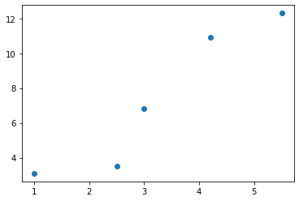

```python
x = np.array([1, 2.5, 3, 4.2, 5.5])
y = np.array([3.1, 3.5, 6.8, 10.9, 12.3])

plt.scatter(x, y);
```

We apply basis expansion to fit a polynomial model to the data (similar to lab_session_02).

```python
def basis_expansion(x: np.array, degree: int = 4) -> np.array:
    """
    Basis expansion (1, x, ..., x^degree)

    :param numpy.array x: vector to be expanded
    :param int degree: degree up to which (included) to perform the expansion
    """
    # Intercept
    Z_list = [np.ones(shape=x.shape)]

    # x^1, x^2, ..., x^degree
    for deg_index in range(1, degree + 1):
        Z_list.append(x**deg_index)

    return np.array(Z_list).T
```

```python
Z = basis_expansion(x)

# Instanciate and fit the model
model = sklearn.linear_model.LinearRegression(fit_intercept=False)
model.fit(Z, y)

print("Coefs:", model.coef_)
```

```
Coefs: [ 35.76946644 -57.32869532  30.30145697  -6.06155522   0.41932713]
```

```python
def plot_regression(x: np.array, model=None, theta=None, degree: int = 4):
    # Compute the model's prediction
    x_pred = np.linspace(x.min(), x.max(), 100)
    Z_pred = basis_expansion(x_pred, degree=degree)
    if model is not None:
        y_pred = model.predict(Z_pred)
    elif theta is not None:
        y_pred = np.dot(Z_pred, theta)
    else:
        raise ValueError('Provide either model or theta')

    # Plot prediction and training set
    fig, ax = plt.subplots(figsize=(18, 8))
    ax.plot(x_pred, y_pred)
    ax.scatter(x, y)
    plt.show();
```

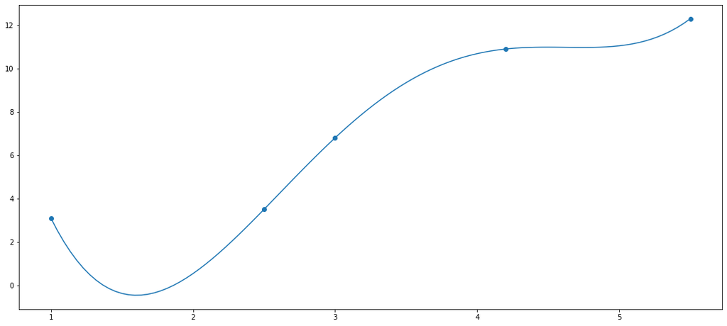

```python
plot_regression(x, model=model)
```

A solution is to reduce the complexity of the model using a lower polynomial degree.

An alternative is to apply a *regularization method* like the *ridge regularization* (a.k.a. *L2 regularization*) which applies a penalty on the value of $\theta$ to constrain it to be as small as possible.

A $\boldsymbol{\theta}$ with small elements usually makes the model simpler and brings better generalization performances.

This L2 regularization is included in the least square method as follows:

$$ \boldsymbol{\theta}^* \leftarrow \arg\min_{\boldsymbol{\theta}} E(\boldsymbol{\theta}) \quad \text{with} \quad E(\boldsymbol{\theta}) = \underbrace{||\boldsymbol{y} - \boldsymbol{X} \boldsymbol{\theta}||^2_2}_{\text{error term}} ~~ + \underbrace{\lambda ||\boldsymbol{\theta}||^2_2}_{\text{regularization}}$$

where $\lambda \in \mathbb{R}^+$ is the *regularization strength* coefficient:

- when $\lambda$ goes to infinity, the regularization term dominates the error term (MSE) and the coefficients $\boldsymbol{\theta}$ tend to zero;
- when $\lambda$ goes to 0, the regularization term looses the importance and eventually the regularization term is ignored;
- $\lambda$ is a *meta* or *hyper parameter*;
- the best $\lambda$ for a problem can be computed empirically or automatically
- we're not interested in the best $\lambda$ *per se* but in the best prediction performance on a test set, *i.e.* achieving a good bias-variance tradeoff. This is made easy by having a single parameter, $\lambda$, to control this tradeoff, and calculating the desired criterion, e.g. MSE on a test set, for many values of $\lambda$ (e.g. grid search);
- to find this "best" lambda (i.e. corresponding to the best MSE on a test set), we usually plot the training and testing errors w.r.t. to lambda, and more generally, w.r.t. model complexity. This will be part of subsequent labs.

### Exercise 2

#### Question 1

On a sheet of paper:

- Compute the analytic formulation of the gradient $\nabla_{\boldsymbol{\theta}} E(\boldsymbol{\theta})$
- Compute the analytic formulation of the optimal parameter $\boldsymbol{\theta^*}$

Recall:

$$ (\boldsymbol{A} + \boldsymbol{B})^T = \boldsymbol{A}^T + \boldsymbol{B}^T $$$$ (\boldsymbol{A} \boldsymbol{B})^T = \boldsymbol{B}^T \boldsymbol{A}^T $$\begin{align} \text{Associativity:} & \quad (\boldsymbol{A} \boldsymbol{B}) \boldsymbol{C} = \boldsymbol{A} (\boldsymbol{B} \boldsymbol{C}) = \boldsymbol{A} \boldsymbol{B} \boldsymbol{C} \\ \text{Non-commutativity:} & \quad \boldsymbol{A} \boldsymbol{B} \neq \boldsymbol{B} \boldsymbol{A} \\ \text{Distributivity:} & \quad \boldsymbol{A} (\boldsymbol{B} + \boldsymbol{C}) = \boldsymbol{A} \boldsymbol{B} + \boldsymbol{A} \boldsymbol{C} \\ & \quad (\boldsymbol{B} + \boldsymbol{C}) \boldsymbol{A} = \boldsymbol{B} \boldsymbol{A} + \boldsymbol{C} \boldsymbol{A} \end{align}

Differential identities for matrices:

\begin{align} d(\boldsymbol{A}) & = 0 \quad \quad \quad \text{if } \boldsymbol{A} \text{ is not function of } \boldsymbol{X} \\ d(a\boldsymbol{X}) & = a d \boldsymbol{X} \quad \quad \text{if } a \text{ is not function of } \boldsymbol{X} \\ d(\boldsymbol{X} +\boldsymbol{Y}) & = d \boldsymbol{X} + d \boldsymbol{Y} \\ d(\boldsymbol{XY}) & = (d \boldsymbol{X}) \boldsymbol{Y} + \boldsymbol{X} (d \boldsymbol{Y}) \\ d(\boldsymbol{X}^T) & = (d \boldsymbol{X})^T \\ \end{align}

Let's develop $E(\boldsymbol{\theta})$:

\begin{align} E(\boldsymbol{\theta}) & = \left( \boldsymbol{y} - \boldsymbol{X} \boldsymbol{\theta} \right)^T \left( \boldsymbol{y} - \boldsymbol{X} \boldsymbol{\theta} \right) + \lambda (\boldsymbol{\theta}^T \boldsymbol{\theta}) \\ & = \left( \boldsymbol{y}^T - (\boldsymbol{X} \boldsymbol{\theta})^T \right) \left( \boldsymbol{y} - \boldsymbol{X} \boldsymbol{\theta} \right) + \lambda \boldsymbol{\theta}^T \boldsymbol{\theta} \\ & = \left( \boldsymbol{y}^T - (\boldsymbol{\theta}^T \boldsymbol{X}^T) \right) \left( \boldsymbol{y} - \boldsymbol{X} \boldsymbol{\theta} \right) + \lambda \boldsymbol{\theta}^T \boldsymbol{\theta} \\ & = \boldsymbol{y}^T \boldsymbol{y} - \boldsymbol{y}^T \boldsymbol{X} \boldsymbol{\theta} - (\boldsymbol{\theta}^T \boldsymbol{X}^T) \boldsymbol{y} + (\boldsymbol{\theta}^T \boldsymbol{X}^T) (\boldsymbol{X} \boldsymbol{\theta}) + \lambda \boldsymbol{\theta}^T \boldsymbol{\theta} \\ & = \boldsymbol{y}^T \boldsymbol{y} - \underbrace{\boldsymbol{y}^T \boldsymbol{X} \boldsymbol{\theta}}_{\text{scalar}} - \underbrace{\boldsymbol{\theta}^T \boldsymbol{X}^T \boldsymbol{y}}_{\text{scalar}} + \boldsymbol{\theta}^T \boldsymbol{X}^T \boldsymbol{X} \boldsymbol{\theta} + \lambda \boldsymbol{\theta}^T \boldsymbol{\theta} \\ \end{align}

Since $\boldsymbol{y}^T \boldsymbol{X} \boldsymbol{\theta}$ is a $1 \times 1$ matrix, or a scalar, and its transpose $(\boldsymbol{y}^T \boldsymbol{X} \boldsymbol{\theta})^T = (\boldsymbol{X} \boldsymbol{\theta})^T \boldsymbol{y} = \boldsymbol{\theta}^T \boldsymbol{X}^T \boldsymbol{y}$ is the same scalar, then $- \boldsymbol{y}^T \boldsymbol{X} \boldsymbol{\theta} - \boldsymbol{\theta}^T \boldsymbol{X}^T \boldsymbol{y} = -2 \boldsymbol{y}^T \boldsymbol{X} \boldsymbol{\theta} = -2 \boldsymbol{\theta}^T \boldsymbol{X}^T \boldsymbol{y}$.

Thus we have:

\begin{align} E(\boldsymbol{\theta}) & = \boldsymbol{y}^T \boldsymbol{y} \underbrace{-2 \boldsymbol{\theta}^T \boldsymbol{X}^T \boldsymbol{y}} + \boldsymbol{\theta}^T \boldsymbol{X}^T \boldsymbol{X} \boldsymbol{\theta} + \lambda \boldsymbol{\theta}^T \boldsymbol{\theta} \\ \end{align}

Then we can write $\nabla_{\boldsymbol{\theta}} E(\boldsymbol{\theta})$:

\begin{align} \nabla_{\boldsymbol{\theta}} E(\boldsymbol{\theta}) & = \nabla_{\boldsymbol{\theta}} \left[ \left( \boldsymbol{y} - \boldsymbol{X} \boldsymbol{\theta} \right)^T \left( \boldsymbol{y} - \boldsymbol{X} \boldsymbol{\theta} \right) + \lambda (\boldsymbol{\theta}^T \boldsymbol{\theta}) \right] \\ & = \nabla_{\boldsymbol{\theta}} \left[ \boldsymbol{y}^T \boldsymbol{y} -2 \boldsymbol{\theta}^T \boldsymbol{X}^T \boldsymbol{y} + \boldsymbol{\theta}^T \boldsymbol{X}^T \boldsymbol{X} \boldsymbol{\theta} + \lambda \boldsymbol{\theta}^T \boldsymbol{\theta} \right] \\ & = \nabla_{\boldsymbol{\theta}} \left[ \boldsymbol{y}^T \boldsymbol{y} \right] + \nabla_{\boldsymbol{\theta}} \left[-2 \boldsymbol{\theta}^T \boldsymbol{X}^T \boldsymbol{y} \right] + \underbrace{\nabla_{\boldsymbol{\theta}} \left[ \boldsymbol{\theta}^T \boldsymbol{X}^T \boldsymbol{X} \boldsymbol{\theta} \right]}_{\text{see recall below}} + \nabla_{\boldsymbol{\theta}} \left[\lambda \boldsymbol{\theta}^T \boldsymbol{\theta} \right] \\ & = -2 \boldsymbol{X}^T \boldsymbol{y} + 2 \boldsymbol{X}^T \boldsymbol{X} \boldsymbol{\theta} + 2\lambda \boldsymbol{I}_p \boldsymbol{\theta} \\ & = \left( \lambda \boldsymbol{I}_p + \boldsymbol{X}^T \boldsymbol{X} \right) 2\boldsymbol{\theta} - 2\boldsymbol{X}^T \boldsymbol{y} \end{align}

where $\boldsymbol{I}_p \in \mathbb{R}^{p \times p}$ is the identity matrix of order $p$.

Recall:

$$ \frac{\partial \boldsymbol{\theta}^T \boldsymbol{A} \boldsymbol{\theta}}{\partial \boldsymbol{\theta}} = 2 \boldsymbol{A} \boldsymbol{\theta} \quad \quad \text{if } \boldsymbol{A} \text{ is not a function of } \boldsymbol{\theta} \text{ and if } \boldsymbol{A} \text{ is a symmetric matrix} $$

Then we can write the formula of the optimal parameter $\boldsymbol{\theta^*}$ (the one that minimize $E(\boldsymbol{\theta})$ i.e. the one such that $\nabla_{\boldsymbol{\theta}} E(\boldsymbol{\theta}) = 0$):

\begin{align} \nabla_{\boldsymbol{\theta^*}} E(\boldsymbol{\theta^*}) & = 0 \\ \Leftrightarrow \left( \lambda \boldsymbol{I}_p + \boldsymbol{X}^T \boldsymbol{X} \right) 2\boldsymbol{\theta^*} - 2\boldsymbol{X}^T \boldsymbol{y} & = 0\\ \Leftrightarrow \left( \lambda \boldsymbol{I}_p + \boldsymbol{X}^T \boldsymbol{X} \right) \boldsymbol{\theta^*} & = \boldsymbol{X}^T \boldsymbol{y}\\ \Leftrightarrow \boldsymbol{\theta^*} & = \left( \lambda \boldsymbol{I}_p + \boldsymbol{X}^T \boldsymbol{X} \right)^{-1} \boldsymbol{X}^T \boldsymbol{y} \end{align}

As $\lambda > 0$, the matrix $\lambda \boldsymbol{I}_p + \boldsymbol{X}^T \boldsymbol{X}$ is always invertible.

#### Question 2

Is it a convex optimization problem like *Ordinary Least Squares* ?

Yes, it's a convex optimization problem like *Ordinary Least Squares*.

$E(\boldsymbol{\theta})$ is a quadratic form (convex function) thus it has a unique global minimum $\boldsymbol{\theta^*}$ where $\nabla_{\boldsymbol{\theta^*}} E(\boldsymbol{\theta^*}) = \boldsymbol{0}$

#### Question 3

Check the following Scikit Learn implementation of the Ridge Regression (more info here: https://scikit-learn.org/stable/modules/linear_model.html#ridge-regression ).

```
Coefs: [ 35.76946644 -57.32869533  30.30145698  -6.06155522   0.41932713]
```

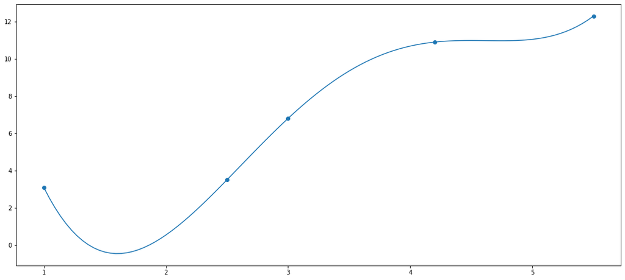

```python
model = sklearn.linear_model.Ridge(alpha=0, fit_intercept=False)
model.fit(Z, y)
coefs = [model.intercept_] + model.coef_
print("Coefs:", coefs)

plot_regression(x, model=model)
```

Change the value of the `alpha` parameter in `sklearn.linear_model.Ridge` and explain what happens (in Scikit Learn the $\lambda$ regression strength is named $\alpha$, and sometimes its inverse is referred to as $C$, e.g., in `LogisticRegression`, see previous lab).

As said earlier, using a higher $\alpha$ yields higher regularization and thus makes the parameter $\theta$ shrink to 0. Conversely, using $\alpha=0$ yields the same parameter $\theta$ as in the previous graph.

#### Question 4

Plot Ridge coefficients as a function of the regularization parameter.

Evaluate the following sequence of regularization strength: `alphas = np.logspace(-2, 5, 50)`.

```python
# Compute paths
alphas = np.logspace(-2, 5, 50)

coefs = []
for a in alphas:
    # Fit a `Ridge` object
    # coefs.append(...)  # TO UNCOMMENT: append the ridge coefficients to the `coefs` list
    ### BEGIN SOLUTION
    ridge = sklearn.linear_model.Ridge(alpha=a, fit_intercept=False)
    ridge.fit(Z, y)
    coefs.append(ridge.coef_)
    ### END SOLUTION
```

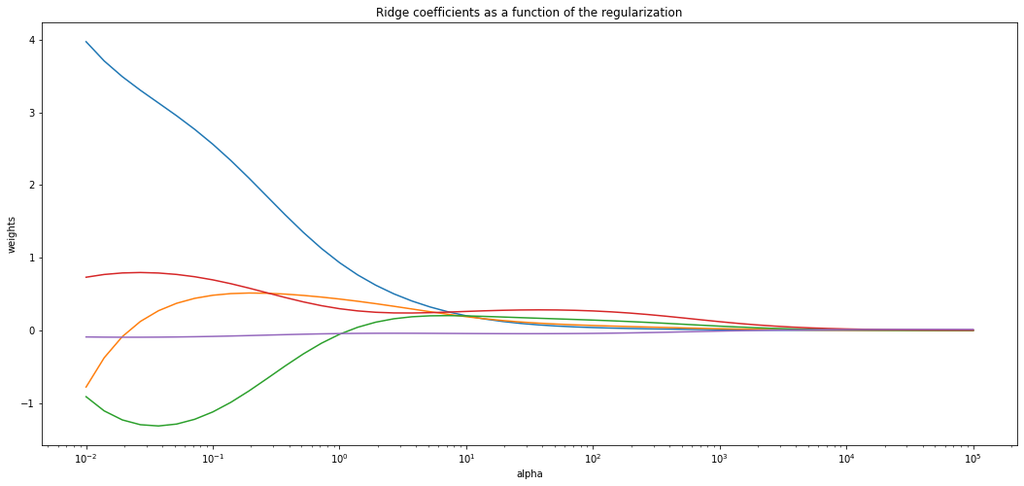

```python
# Display results
fig, ax = plt.subplots(figsize=(18, 8))
ax.plot(alphas, coefs)
ax.set_xscale('log')
plt.xlabel('alpha')
plt.ylabel('weights')
plt.title('Ridge coefficients as a function of the regularization')
plt.axis('tight')
plt.show()
```

#### Question 5

Update the following function to implement the ridge regression in Python (without using Scikit Learn). Check it as in question 3.

```python
def ridge_regression(X, y, lambda_):
    XX = np.dot(X.T, X)
    Xy = np.dot(X.T, y)
    # invXX = ...
    # theta = ...
    ### BEGIN SOLUTION
    I = lambda_ * np.eye(XX.shape[0])
    Xy = np.dot(X.T, y)
    invXX = np.linalg.inv(I + XX)
    theta = np.dot(invXX, Xy)
    ### END SOLUTION
    return theta
```

```
Coefs: [ 0.29158342  0.24162754  0.20355225  0.24796927 -0.04009718]
```

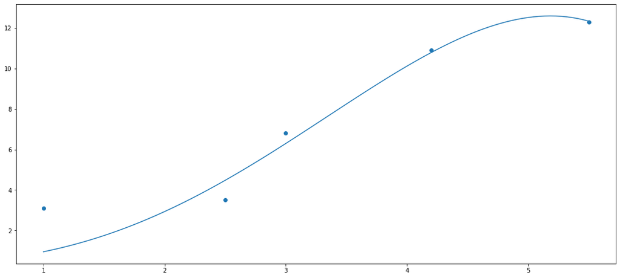

```python
theta = ridge_regression(Z, y, lambda_=6.)

print("Coefs:", theta)

plot_regression(x, theta=theta)
```

## Ridge Logistic Regression

### Exercise 3

Let's use our 2D classification example from lab_session_03.

```python
df = gen_2d_classification_samples(n_samples=50, nclass=2)
```

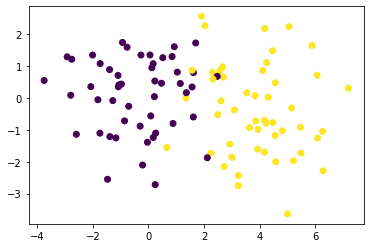

```python
x_min, x_max = np.array((df.x1, df.x2))[0, :].min() - .5, np.array((df.x1, df.x2))[0, :].max() + .5
y_min, y_max = np.array((df.x1, df.x2))[1, :].min() - .5, np.array((df.x1, df.x2))[1, :].max() + .5
h = .02  # step size in the mesh
xx, yy = np.meshgrid(np.arange(x_min, x_max, h), np.arange(y_min, y_max, h))
plt.scatter(df.x1, df.x2, c=df.y);
```

We used gradient descent to fit a Logistic Regression and draw a linear decision boundary between these two classes.

Recall the `LogisticRegression` class:

```python
logistic_regression = sklearn.linear_model.LogisticRegression(C = 1e9).fit(
    df[['x1', 'x2']].values,
    df.y.values - 1)
```

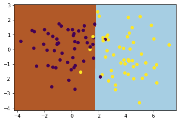

```python
Z = logistic_regression.predict_proba(np.c_[xx.ravel(), yy.ravel()])[:, 0]
plt.pcolormesh(xx, yy, (Z.reshape(xx.shape) > 0.5) * 1, cmap=plt.cm.Paired)
plt.scatter(df.x1, df.x2, c=df.y - 1);
```

Let's try doing polynomial logistic regression:

```python
logistic_regression = sklearn.linear_model.LogisticRegression(C = 1e9).fit(
    np.array([df.x1, df.x2, df.x1 ** 2, df.x2 ** 2, df.x1 ** 3, df.x2 ** 3]).T,
    np.array(df.y) - 1)
```

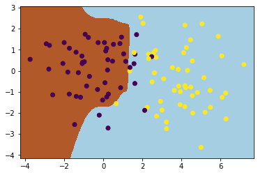

```python
Z = logistic_regression.predict_proba(np.c_[xx.ravel(), yy.ravel(),
                                            xx.ravel() ** 2, yy.ravel() ** 2,
                                            xx.ravel() ** 3, yy.ravel()] ** 3)[:, 0]
plt.pcolormesh(xx, yy, (Z.reshape(xx.shape) > 0.5) * 1, cmap=plt.cm.Paired)
plt.scatter(df.x1, df.x2, c=df.y - 1);
```

This is a relatively poor fit. Just like linear regression, let's try to regularize logistic regression with a ridge penalty ($\lambda ||\boldsymbol{\theta}||_2^2$).

On a sheet of paper, compute the analytic formulation of the gradient $\nabla_{\boldsymbol{\theta}} E(\boldsymbol{\theta})$

*Note*: this is similar to Exercise 2 **but** the error function is now the log-loss.

Recall:

$$ (\boldsymbol{A} + \boldsymbol{B})^T = \boldsymbol{A}^T + \boldsymbol{B}^T $$$$ (\boldsymbol{A} \boldsymbol{B})^T = \boldsymbol{B}^T \boldsymbol{A}^T $$\begin{align} \text{Associativity:} & \quad (\boldsymbol{A} \boldsymbol{B}) \boldsymbol{C} = \boldsymbol{A} (\boldsymbol{B} \boldsymbol{C}) = \boldsymbol{A} \boldsymbol{B} \boldsymbol{C} \\ \text{Non-commutativity:} & \quad \boldsymbol{A} \boldsymbol{B} \neq \boldsymbol{B} \boldsymbol{A} \\ \text{Distributivity:} & \quad \boldsymbol{A} (\boldsymbol{B} + \boldsymbol{C}) = \boldsymbol{A} \boldsymbol{B} + \boldsymbol{A} \boldsymbol{C} \\ & \quad (\boldsymbol{B} + \boldsymbol{C}) \boldsymbol{A} = \boldsymbol{B} \boldsymbol{A} + \boldsymbol{C} \boldsymbol{A} \end{align}

Differential identities for matrices:

\begin{align} d(\boldsymbol{A}) & = 0 \quad \quad \quad \text{if } \boldsymbol{A} \text{ is not function of } \boldsymbol{X} \\ d(a\boldsymbol{X}) & = a d \boldsymbol{X} \quad \quad \text{if } a \text{ is not function of } \boldsymbol{X} \\ d(\boldsymbol{X} +\boldsymbol{Y}) & = d \boldsymbol{X} + d \boldsymbol{Y} \\ d(\boldsymbol{XY}) & = (d \boldsymbol{X}) \boldsymbol{Y} + \boldsymbol{X} (d \boldsymbol{Y}) \\ d(\boldsymbol{X}^T) & = (d \boldsymbol{X})^T \\ \end{align}

We can use the $C$ parameter in `sklearn`, inversely proportional to $\lambda$, to fit such a penalization.

You can play with the parameter $C$, as well as the penalty and solver arguments. [See the documentation](https://scikit-learn.org/stable/modules/generated/sklearn.linear_model.LogisticRegression.html).

```python
logistic_regression = sklearn.linear_model.LogisticRegression(C = 0.000001, penalty='l2').fit(
    np.array([df.x1, df.x2, df.x1 ** 2, df.x2 ** 2, df.x1 ** 3, df.x2 ** 3]).T,
    np.array(df.y) - 1)
```

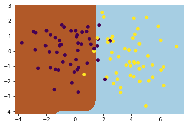

```python
Z = logistic_regression.predict_proba(np.c_[xx.ravel(), yy.ravel(),
                                            xx.ravel() ** 2, yy.ravel() ** 2,
                                            xx.ravel() ** 3, yy.ravel()] ** 3)[:, 0]
plt.pcolormesh(xx, yy, (Z.reshape(xx.shape) > 0.5) * 1, cmap=plt.cm.Paired)
plt.scatter(df.x1, df.x2, c=df.y - 1);
```

## Weighted Least Squares

For some regression problems, it may be helpful to give different importance to examples in the *learning set* $\mathcal{D} = \{(\boldsymbol{x^{(i)}}, y^{(i)})\}_{1 \leq i \leq n}$ that is to say associate a weight $\omega^{(i)}$ to example $\boldsymbol{x}^{(i)}$ in order to prioritize some of them and ignore some others (e.g. outliers).

Introducing these weights in the method of Least Square, the regression problem becomes:

$$E(\boldsymbol{\theta}) = \sum_{i=1}^n \omega^{(i)} (y^{(i)} - \boldsymbol{x}^{(i)} \boldsymbol{\theta})^2$$

In order to use the matrix notation, we put weights $\omega^{(i)}$ in the diagonal of the following matrix $\Omega$:

$$ \Omega = \begin{pmatrix} \omega^{(1)} & 0 & \cdots & 0 \\ 0 & \omega^{(2)} & \cdots & 0 \\ \vdots & \vdots & \ddots & \vdots \\ 0 & 0 & \cdots & \omega^{(n)} \\ \end{pmatrix} $$

Then we can write:

$$E(\boldsymbol{\theta}) = (\boldsymbol{y} - \boldsymbol{X} \boldsymbol{\theta})^T \Omega (\boldsymbol{y} - \boldsymbol{X} \boldsymbol{\theta})$$

with: $$ \boldsymbol{X} = \begin{pmatrix} 1 & x_1^{(1)} & \dots & x_p^{(1)} \\ \vdots & \vdots & \dots & \vdots \\ 1 & x_1^{(n)} & \dots & x_p^{(n)} \end{pmatrix} \quad \quad \boldsymbol{y} = \begin{pmatrix} y^{(1)} \\ \vdots \\ y^{(n)} \end{pmatrix} \quad \quad \boldsymbol{\theta} = \begin{pmatrix} \theta_0 \\ \vdots \\ \theta_p \end{pmatrix} $$

### Exercise 4

#### Question 1

On a sheet of paper:

- Compute the analytic formulation of the gradient $\nabla_{\boldsymbol{\theta}} E(\boldsymbol{\theta})$
- Compute the analytic formulation of the optimal parameter $\boldsymbol{\theta^*}$

Recall:

$$ (\boldsymbol{A} + \boldsymbol{B})^T = \boldsymbol{A}^T + \boldsymbol{B}^T $$$$ (\boldsymbol{A} \boldsymbol{B})^T = \boldsymbol{B}^T \boldsymbol{A}^T $$\begin{align} \text{Associativity:} & \quad (\boldsymbol{A} \boldsymbol{B}) \boldsymbol{C} = \boldsymbol{A} (\boldsymbol{B} \boldsymbol{C}) = \boldsymbol{A} \boldsymbol{B} \boldsymbol{C} \\ \text{Non-commutativity:} & \quad \boldsymbol{A} \boldsymbol{B} \neq \boldsymbol{B} \boldsymbol{A} \\ \text{Distributivity:} & \quad \boldsymbol{A} (\boldsymbol{B} + \boldsymbol{C}) = \boldsymbol{A} \boldsymbol{B} + \boldsymbol{A} \boldsymbol{C} \\ & \quad (\boldsymbol{B} + \boldsymbol{C}) \boldsymbol{A} = \boldsymbol{B} \boldsymbol{A} + \boldsymbol{C} \boldsymbol{A} \end{align}

Differential identities for matrices:

\begin{align} d(\boldsymbol{A}) & = 0 \quad \quad \quad \text{if } \boldsymbol{A} \text{ is not function of } \boldsymbol{X} \\ d(a\boldsymbol{X}) & = a d \boldsymbol{X} \quad \quad \text{if } a \text{ is not function of } \boldsymbol{X} \\ d(\boldsymbol{X} +\boldsymbol{Y}) & = d \boldsymbol{X} + d \boldsymbol{Y} \\ d(\boldsymbol{XY}) & = (d \boldsymbol{X}) \boldsymbol{Y} + \boldsymbol{X} (d \boldsymbol{Y}) \\ d(\boldsymbol{X}^T) & = (d \boldsymbol{X})^T \\ \end{align}

Lets develop $E(\boldsymbol{\theta})$:

\begin{align} E(\boldsymbol{\theta}) & = \left( \boldsymbol{y} - \boldsymbol{X} \boldsymbol{\theta} \right)^T \boldsymbol{\Omega} \left( \boldsymbol{y} - \boldsymbol{X} \boldsymbol{\theta} \right) \\ & = \left( \boldsymbol{y}^T - (\boldsymbol{X} \boldsymbol{\theta})^T \right) \boldsymbol{\Omega} \left( \boldsymbol{y} - \boldsymbol{X} \boldsymbol{\theta} \right) \\ & = \left( \boldsymbol{y}^T - (\boldsymbol{\theta}^T \boldsymbol{X}^T) \right) \boldsymbol{\Omega} \left( \boldsymbol{y} - \boldsymbol{X} \boldsymbol{\theta} \right) \\ & = \left( \boldsymbol{y}^T \boldsymbol{\Omega} - \boldsymbol{\theta}^T \boldsymbol{X}^T \boldsymbol{\Omega} \right) \left( \boldsymbol{y} - \boldsymbol{X} \boldsymbol{\theta} \right) \\ & = \boldsymbol{y}^T \boldsymbol{\Omega} \boldsymbol{y} - \underbrace{\boldsymbol{y}^T \boldsymbol{\Omega} \boldsymbol{X} \boldsymbol{\theta}}_{\text{scalar}} - \underbrace{\boldsymbol{\theta}^T \boldsymbol{X}^T \boldsymbol{\Omega} \boldsymbol{y}}_{\text{scalar}} + \boldsymbol{\theta}^T \boldsymbol{X}^T \boldsymbol{\Omega} \boldsymbol{X} \boldsymbol{\theta} \\ \end{align}

Since $\boldsymbol{y}^T \boldsymbol{\Omega} \boldsymbol{X} \boldsymbol{\theta}$ is a $1 \times 1$ matrix, or a scalar, and its transpose $(\boldsymbol{y}^T \boldsymbol{\Omega} \boldsymbol{X} \boldsymbol{\theta})^T = (\boldsymbol{\Omega} \boldsymbol{X} \boldsymbol{\theta})^T \boldsymbol{y} = (\boldsymbol{X} \boldsymbol{\theta})^T \boldsymbol{\Omega}^T \boldsymbol{y} = \boldsymbol{\theta}^T \boldsymbol{X}^T \boldsymbol{\Omega}^T \boldsymbol{y} = \boldsymbol{\theta}^T \boldsymbol{X}^T \boldsymbol{\Omega} \boldsymbol{y}$ is the same scalar ($\boldsymbol{\Omega} = \boldsymbol{\Omega}^T$ as $\boldsymbol{\Omega}$ is a diagonal matrix), then $- \boldsymbol{y}^T \boldsymbol{\Omega} \boldsymbol{X} \boldsymbol{\theta} - \boldsymbol{\theta}^T \boldsymbol{X}^T \boldsymbol{\Omega} \boldsymbol{y} = -2 \boldsymbol{y}^T \boldsymbol{\Omega} \boldsymbol{X} \boldsymbol{\theta} = -2 \boldsymbol{\theta}^T \boldsymbol{X}^T \boldsymbol{\Omega} \boldsymbol{y}$.

Thus we have:

\begin{align} E(\boldsymbol{\theta}) & = \boldsymbol{y}^T \boldsymbol{\Omega} \boldsymbol{y} -2 \boldsymbol{\theta}^T \boldsymbol{X}^T \boldsymbol{\Omega} \boldsymbol{y} + \boldsymbol{\theta}^T \boldsymbol{X}^T \boldsymbol{\Omega} \boldsymbol{X} \boldsymbol{\theta} \\ \end{align}

Then we can write $\nabla_{\boldsymbol{\theta}} E(\boldsymbol{\theta})$:

\begin{align} \nabla_{\boldsymbol{\theta}} E(\boldsymbol{\theta}) & = \nabla_{\boldsymbol{\theta}} \left[ \left( \boldsymbol{y} - \boldsymbol{X} \boldsymbol{\theta} \right)^T \boldsymbol{\Omega} \left( \boldsymbol{y} - \boldsymbol{X} \boldsymbol{\theta} \right) \right] \\ & = \nabla_{\boldsymbol{\theta}} \left[ \boldsymbol{y}^T \boldsymbol{\Omega} \boldsymbol{y} -2 \boldsymbol{\theta}^T \boldsymbol{X}^T \boldsymbol{\Omega} \boldsymbol{y} + \boldsymbol{\theta}^T \boldsymbol{X}^T \boldsymbol{\Omega} \boldsymbol{X} \boldsymbol{\theta} \right] \\ & = \nabla_{\boldsymbol{\theta}} \left[ \boldsymbol{y}^T \boldsymbol{\Omega} \boldsymbol{y} \right] + \nabla_{\boldsymbol{\theta}} \left[-2 \boldsymbol{\theta}^T \boldsymbol{X}^T \boldsymbol{\Omega} \boldsymbol{y} \right] + \underbrace{\nabla_{\boldsymbol{\theta}} \left[ \boldsymbol{\theta}^T \boldsymbol{X}^T \boldsymbol{\Omega} \boldsymbol{X} \boldsymbol{\theta} \right]}_{\text{see recall below}} \\ & = -2 \boldsymbol{X}^T \boldsymbol{\Omega} \boldsymbol{y} + 2 \boldsymbol{X}^T \boldsymbol{\Omega} \boldsymbol{X} \boldsymbol{\theta} \\ & = -2 \boldsymbol{X}^T \boldsymbol{\Omega} (\boldsymbol{y} - \boldsymbol{X\theta}) \end{align}

Recall:

$$ \nabla_{\boldsymbol{\theta}} \left[\boldsymbol{\theta}^T \boldsymbol{A} \boldsymbol{\theta} \right] = 2 \boldsymbol{A} \boldsymbol{\theta} \quad \quad \text{if } \boldsymbol{A} \text{ is not a function of } \boldsymbol{\theta} \text{ and if } \boldsymbol{A} \text{ is a symmetric matrix} $$

Then we can write the formula of the optimal parameter $\boldsymbol{\theta^*}$ (the one that minimize $E$ i.e. the one such that $\nabla_{\boldsymbol{\theta^*}} E(\boldsymbol{\theta^*}) = 0$):

\begin{align} \nabla_{\boldsymbol{\theta^*}} E(\boldsymbol{\theta^*}) & = 0 \\ \Leftrightarrow -2 \boldsymbol{X}^T \boldsymbol{\Omega} (\boldsymbol{y} - \boldsymbol{X\theta^*}) & = 0\\ \Leftrightarrow \boldsymbol{X}^T \boldsymbol{\Omega} (\boldsymbol{y} - \boldsymbol{X\theta^*}) & = 0\\ \Leftrightarrow \boldsymbol{X^T \Omega y} - \boldsymbol{X^T \Omega X\theta^*} & = 0\\ \Leftrightarrow \boldsymbol{X^T \Omega X\theta^*} & = \boldsymbol{X^T \Omega y} \\ \Leftrightarrow \boldsymbol{\theta^*} & = (\boldsymbol{X^T \Omega X})^{-1} \boldsymbol{X}^T \boldsymbol{\Omega} \boldsymbol{y} \end{align}

#### Question 2

Is it a convex optimization problem like *Ordinary Least Squares* ?

Yes, it's a convex optimization problem like *Ordinary Least Squares*.

#### Question 3

We have the following dataset and weights:

```python
X = np.array([[1, 1],
              [1, 2],
              [1, 3],
              [1, 4],
              [1, 5]])

y = np.array([1.8, 4.5, 3.4, 3.6, 4.2]).reshape([-1, 1])

Omega = np.diag([1, 2, 3, 2, 1])

Omega
```

```
array([[1, 0, 0, 0, 0],
       [0, 2, 0, 0, 0],
       [0, 0, 3, 0, 0],
       [0, 0, 0, 2, 0],
       [0, 0, 0, 0, 1]])
```

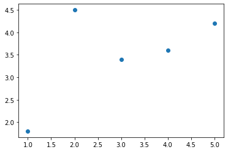

```python
plt.scatter(X[:,1], y);
```

Complete the following Python implementation of the `weighted_least_squares()` procedure. It should return the optimal parameter $\boldsymbol{\theta^*}$ using the method of Least Square for the matrix of weights $\Omega$.

Numpy recall:

- The transpose of a matrix `X` is obtained with `X.T`
- The inverse of a matrix `X` is obtained with `np.linalg.inv(X)`
- The product of two matrices `X` and `Y` is obtained with `np.dot(X, Y)` or `np.matmul(X, Y)` or `X @ Y`
- The dot product of a matrix `X` and a vector `y` is obtained with `np.dot(X, y)`

```python
def weighted_least_squares(X, Omega, y):
    # theta = ...  # TO UNCOMMENT AND COMPLETE
    ### BEGIN SOLUTION
    X_Omega_y = np.dot(np.dot(X.T, Omega), y)
    X_Omega_X = np.dot(np.dot(X.T, Omega), X)
    inv_X_Omega_X = np.linalg.inv(X_Omega_X)

    theta = np.dot(inv_X_Omega_X, X_Omega_y)
    ### END SOLUTION
    return(theta)
```

```python
theta = weighted_least_squares(X, Omega, y)
assert len(theta) == 2
### BEGIN HIDDEN TESTS
assert int(theta[0][0]) == 2
assert int(theta[1][0]) == 0
### END HIDDEN TESTS
```

#### Question 4

Check graphically your model using the following code:

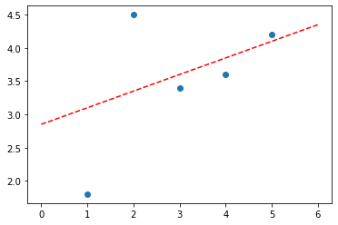

```python
plot_regression_1d(X, y, theta, x_min=0, x_max=6)
```

#### Question 5

Change the weights in $\Omega$ to ignore the second point $x = 2$ (give the same weight to all other points) then recompute $\theta$ using `weighted_least_squares()` and check the results on plots with `plot_regression_1d()`.

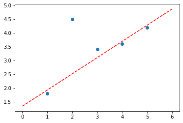

```python
# Omega = ...
### BEGIN SOLUTION
Omega = np.diag([1, 0, 1, 1, 1])
### END SOLUTION
theta = weighted_least_squares(X, Omega, y)
plot_regression_1d(X, y, theta, x_min=0, x_max=6)
```

```python
assert len(theta) == 2
### BEGIN HIDDEN TESTS
assert int(theta[0][0]) == 1
assert int(theta[1][0]) == 0
### END HIDDEN TESTS
```

## Nadaraya-Watson Kernel Regression (Bonus)

Like k-Nearest Neighbors, *Nadaraya-Watson Kernel Regression* is a non-parametric model, i.e. decisions are made according to known examples from the *learning set* $\mathcal{D} = \{(y^{(i)}, \boldsymbol{x^{(i)}})\}_{1 \leq i \leq n}$ of $n$ examples and considering a kind of proximity relationship.

$$ y = f(\boldsymbol{x}) = \frac{\sum^{n}_{i=1} K(\boldsymbol{x}^{(i)}, \boldsymbol{x}) ~ y^{(i)}}{\sum^{n}_{j=1} K(\boldsymbol{x}^{(j)}, \boldsymbol{x})} = \sum^{n}_{i=1} y^{(i)} \omega^{(i)} $$

with $\sum^{n}_{i=1} \omega^{(i)} = 1$

Recall about the notation used here:

- $\boldsymbol{x}^{(i)}$ is the feature (input) vector of the $i^{\text{th}}$ example in $\mathcal{D}$ (and $y^{(i)}$ is its label). Beware: $\boldsymbol{x}^{(i)}$ is not the $i^{\text{th}}$ power of $\boldsymbol{x}$ (we will write $\boldsymbol{x}^{(i)2}$ for the square of $\boldsymbol{x}^{(i)}$)!
- $x_i$ is the value of $\boldsymbol{x}$ on the $i^{\text{th}}$ dimension

### Exercise 5

#### Question 1

Implement the Gaussian kernel $K$ in the following `gaussian_kernel()` Python function.

$$ K(\boldsymbol{u}, \boldsymbol{v}) = \exp\left(\frac{-||\boldsymbol{u} - \boldsymbol{v}||^2_2}{2 \sigma^2} \right) $$

where $\sigma$ is a parameter equal to $1$ by default.

You can assume $u$ and $v$ to be simple scalars to simplify this Python implementation (i.e. restrict yourself to regression problem with 1 dimension inputs $x \in \mathbb{R}$).

Recall: $e^x$ is written `math.exp(x)` in Python.

```python
def gaussian_kernel(u, v, sigma = 1.):
    # return expression above
    ### BEGIN SOLUTION
    square_dist = (float(u) - float(v))**2
    return math.exp( -square_dist / (2. * sigma**2) )
    ### END SOLUTION
```

```python
assert gaussian_kernel(0,0) == 1
assert gaussian_kernel(1,0) == math.exp(-1/2)
### BEGIN HIDDEN TESTS
assert gaussian_kernel(1,1) == 1
assert gaussian_kernel(0,1) == math.exp(-1/2)
### END HIDDEN TESTS
```

#### Question 2

Implement the Nadaraya-Watson kernel regression in the following `kernel_regression()` Python function.

$$ \text{kernel_regression}(\boldsymbol{x}, \mathcal{D}) = \frac{\sum^{n}_{i=1} K(\boldsymbol{x}^{(i)}, \boldsymbol{x}) ~ y^{(i)}}{\sum^{n}_{j=1} K(\boldsymbol{x}^{(j)}, \boldsymbol{x})} = y $$

You can assume that $x$ is a scalar to simplify the Python implementation. We assume `dataset` contains examples $\mathcal{D} = \{(\boldsymbol{x^{(i)}}, y^{(i)})\}_{1 \leq i \leq n}$ in a Pandas DataFrame having:

- one row per example
- a column "x" containing the examples' features (only one dimension here)
- a column "y" containing the examples' labels

**Hint**: you can use the following `for` loop to compute $\sum K(\boldsymbol{x}^{(i)}, \boldsymbol{x}) ~ y^{(i)}$: `for xi, yi in zip(df.x, df.y)`.

```python
def kernel_regression(x, dataset):
    # Hint: calculate numerator and denominator separately with list comprehensions
    ### BEGIN SOLUTION
    w1 = sum([gaussian_kernel(xi, x) * yi for xi, yi in zip(dataset.x, dataset.y)])
    w2 = sum([gaussian_kernel(xj, x) for xj in dataset.x])
    return w1 / w2
    ### END SOLUTION
```

```python
assert kernel_regression(1, pd.DataFrame({"x": [0], "y": [0]})) == 0
### BEGIN HIDDEN TESTS
assert kernel_regression(1, pd.DataFrame({"x": [1], "y": [1]})) == 1
### END HIDDEN TESTS
```

We have the following dataset:

```python
dataset = pd.DataFrame([[2., 0.],
                        [5., 2.],
                        [7., 1.],
                        [10., 2.],
                        [14., 4.],
                        [16., 3.],
                        [17., 0.]], columns=['x', 'y'])
dataset
```

|  | x | y |
| --- | --- | --- |
| 0 | 2.0 | 0.0 |
| 1 | 5.0 | 2.0 |
| 2 | 7.0 | 1.0 |
| 3 | 10.0 | 2.0 |
| 4 | 14.0 | 4.0 |
| 5 | 16.0 | 3.0 |
| 6 | 17.0 | 0.0 |

Check your `kernel_regression()` function with the following code:

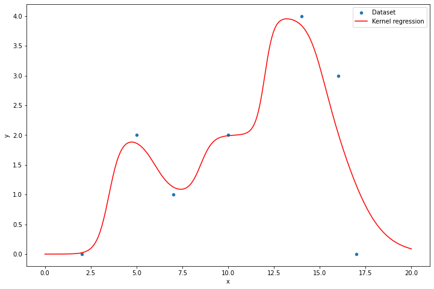

```python
x_pred = np.linspace(0., 20., 200)
y_pred = [kernel_regression(x, dataset) for x in x_pred]

ax = dataset.plot.scatter(x='x', y='y', label="Dataset", figsize=(12,8))
ax.plot(x_pred, y_pred, "-r", label="Kernel regression")
plt.legend();
```